# Tugas MPDW yg ke-sekian

Dimas Ragamulia M0401231901

2025-10-06

# Library

```r
library(ggplot2)
library(tsibble)
library(tseries)
library(MASS)
library(forecast)
library(TSA)
library(TTR)
library(aTSA)
library(graphics)
library(readxl)
```

# Impor Data

```r
data <- read_excel("C:/Users/DELL Inspiron/Downloads/data google mpdw.xlsx")
data1 <- data[401:600, ]
data1.ts <- ts(data1$AI_Revenue_USD_Mn)
data1
```

```
## # A tibble: 200 × 2
##    Date                AI_Revenue_USD_Mn
##    <dttm>                          <dbl>
##  1 2023-05-12 00:00:00              128.
##  2 2023-05-13 00:00:00              129.
##  3 2023-05-14 00:00:00              129.
##  4 2023-05-15 00:00:00              128.
##  5 2023-05-16 00:00:00              130.
##  6 2023-05-17 00:00:00              129.
##  7 2023-05-18 00:00:00              129.
##  8 2023-05-19 00:00:00              129.
##  9 2023-05-20 00:00:00              129.
## 10 2023-05-21 00:00:00              129.
## # ℹ 190 more rows
```

Selanjutnya, kita akan membagi menjadi data latih (80%) untuk membangun model dan data uji (20%) untuk validasi peramalan.

```r
data.train <- data1.ts [1:160]
data.test <- data1.ts [161:200]
```

# Eksplorasi Data

## Plot Deret Waktu

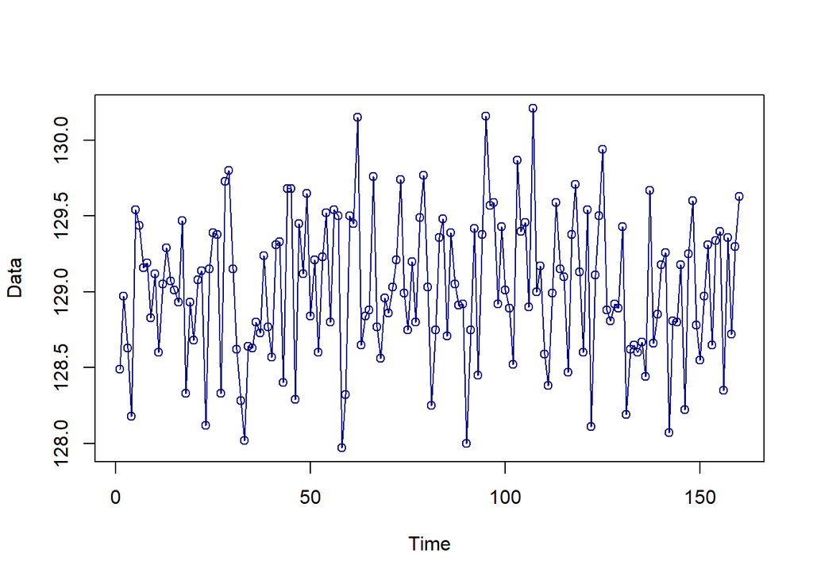

```r
#--PLOT TIME SERIES--#
plot(data.train,
     col = "navyblue",
     lwd = 1,
     type = "o",
     xlab = "Time",
     ylab = "Data")
```

Berdasarkan plot deret waktu di atas, data berfluktuasi di sekitar nilai tengah sekitar 129 dengan ragam yang relatif konstan, sehingga dapat dikatakan **stasioner dalam rataan dan ragam**. Selanjutnya, stasioneritas akan diuji menggunakan plot ACF dan uji ADF.

## Plot ACF dan Uji Formal (Uji ADF)

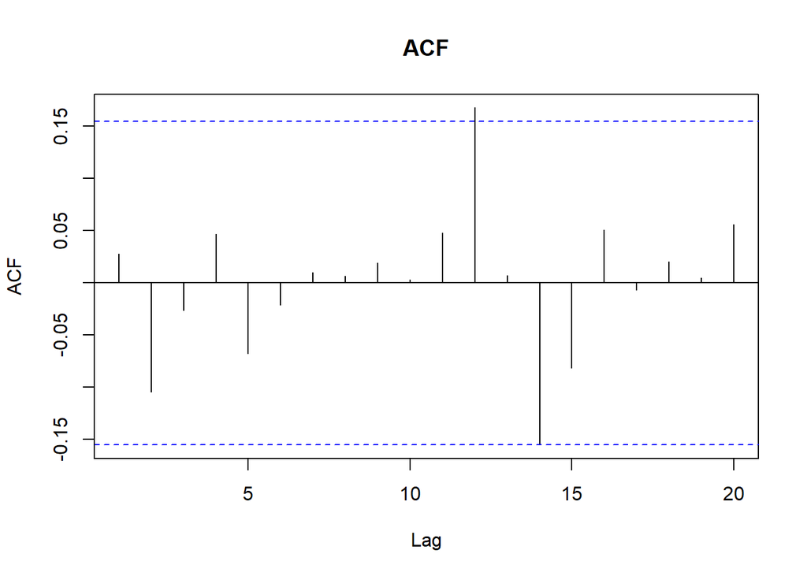

```r
#--CEK KESTASIONERAN---#
acf(data.train, main="ACF", lag.max=20)
```

Berdasarkan plot ACF di atas, terlihat bahwa sebagian besar nilai autokorelasi berada dalam batas kepercayaan dan tidak menunjukkan pola yang jelas. Hal ini mengindikasikan bahwa **data bersifat acak dan stasioner**, serta **tidak terdapat autokorelasi yang signifikan** pada lag tertentu.

```r
tseries::adf.test(data.train)
```

```
##
##  Augmented Dickey-Fuller Test
##
## data:  data.train
## Dickey-Fuller = -5.3339, Lag order = 5, p-value = 0.01
## alternative hypothesis: stationary
```

```r
#stasioner
```

$H_0$ : Data tidak stasioner dalam rataan

$H_1$ : Data stasioner dalam rataan

Berdasarkan uji ADF tersebut, didapat p-value sebesar 0.01 yang lebih kecil dari taraf nyata 5% sehingga tolak $H_0$ dan menandakan bahwa data stasioner dalam rataan. Hal ini sesuai dengan hasil eksplorasi menggunakan plot time series dan plot ACF.

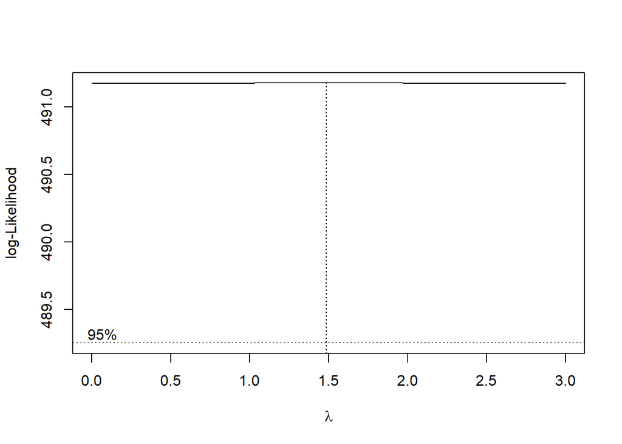

```r
index <- seq_along(data.train)  # otomatis 1 sampai panjang data.train

bc <- MASS::boxcox(data.train ~ index, lambda = seq(0, 3, by = 0.1))
```

```r
# Nilai lambda optimal
lambda <- bc$x[which.max(bc$y)]
lambda
```

```
## [1] 1.484848
```

```r
# Selang kepercayaan 95% untuk lambda
bc$x[bc$y > max(bc$y) - 0.5 * qchisq(.95, 1)]
```

```
##   [1] 0.00000000 0.03030303 0.06060606 0.09090909 0.12121212 0.15151515
##   [7] 0.18181818 0.21212121 0.24242424 0.27272727 0.30303030 0.33333333
##  [13] 0.36363636 0.39393939 0.42424242 0.45454545 0.48484848 0.51515152
##  [19] 0.54545455 0.57575758 0.60606061 0.63636364 0.66666667 0.69696970
##  [25] 0.72727273 0.75757576 0.78787879 0.81818182 0.84848485 0.87878788
##  [31] 0.90909091 0.93939394 0.96969697 1.00000000 1.03030303 1.06060606
##  [37] 1.09090909 1.12121212 1.15151515 1.18181818 1.21212121 1.24242424
##  [43] 1.27272727 1.30303030 1.33333333 1.36363636 1.39393939 1.42424242
##  [49] 1.45454545 1.48484848 1.51515152 1.54545455 1.57575758 1.60606061
##  [55] 1.63636364 1.66666667 1.69696970 1.72727273 1.75757576 1.78787879
##  [61] 1.81818182 1.84848485 1.87878788 1.90909091 1.93939394 1.96969697
##  [67] 2.00000000 2.03030303 2.06060606 2.09090909 2.12121212 2.15151515
##  [73] 2.18181818 2.21212121 2.24242424 2.27272727 2.30303030 2.33333333
##  [79] 2.36363636 2.39393939 2.42424242 2.45454545 2.48484848 2.51515152
##  [85] 2.54545455 2.57575758 2.60606061 2.63636364 2.66666667 2.69696970
##  [91] 2.72727273 2.75757576 2.78787879 2.81818182 2.84848485 2.87878788
##  [97] 2.90909091 2.93939394 2.96969697 3.00000000
```

# Spesifikasi Model

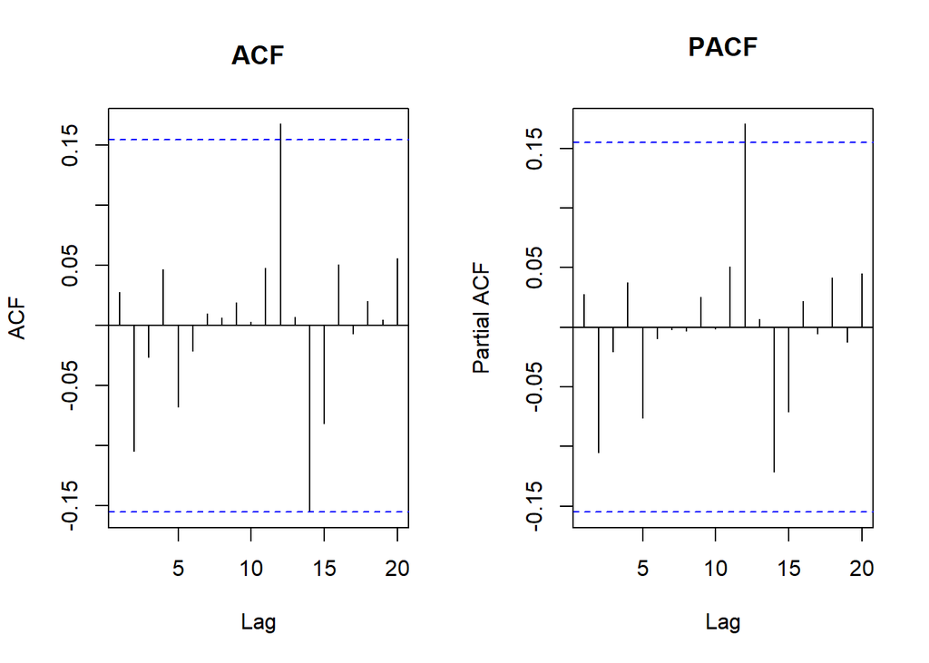

```r
#SPESIFIKASI MODEL
par(mfrow = c(1,2))
acf(data.train, main="ACF", lag.max=20) #ARIMA(0,0,0)
pacf(data.train, main="PACF", lag.max=20) #ARIMA(0,0,0)
```

```r
par(mfrow = c(1,1))
```

Berdasarkan plot ACF dan PACF di atas, terlihat bahwa kedua plot tidak menunjukkan pola pemotongan (cut off) yang jelas, dan sebagian besar lag berada dalam batas kepercayaan. Hal ini mengindikasikan bahwa **data bersifat acak dan stasioner**, serta **tidak terdapat autokorelasi yang signifikan**. Dengan demikian, model yang sesuai kemungkinan adalah **ARIMA(0,0,0)** atau model white noise.

```r
eacf(data.train)
```

```
## AR/MA
##   0 1 2 3 4 5 6 7 8 9 10 11 12 13
## 0 o o o o o o o o o o o  x  o  o
## 1 x o o o o o o o o o o  x  o  o
## 2 x x o o o o o o o o o  o  o  o
## 3 x o x o o o o o o o o  o  o  o
## 4 x o x x o o o o o o o  o  o  o
## 5 o o o x x o o o o o o  o  o  o
## 6 x o o x o o o o o o o  o  o  o
## 7 x o o o o o o o o o o  o  o  o
```

```r
#ARIMA(1,0,0), ARIMA(1,0,1), ARIMA(1,0,2), dan ARIMA(1,0,3)
#Terdapat 5 model tentatif
```

ARIMA(1,0,0), ARIMA(1,0,1), ARIMA(1,0,2), dan ARIMA(1,0,3).

# Pendugaan Parameter

Selanjutnya akan dilakukan pendugaan parameter kelima model ARIMA yang terbentuk sebelumnya. Pendugaan dilakukan dengan fungsi Arima() yang dilanjutkan dengan melihat nilai AIC pada ringkasan data dan melihat signifikansi parameter.

```r
#---PENDUGAAN PARAMETER MODEL---#
model1.data=Arima(data.train, order=c(0,0,0),method="ML")
summary(model1.data) #AIC=219
```

```
## Series: data.train
## ARIMA(0,0,0) with non-zero mean
##
## Coefficients:
##           mean
##       129.0221
## s.e.    0.0375
##
## sigma^2 = 0.2259:  log likelihood = -107.5
## AIC=219   AICc=219.08   BIC=225.15
##
## Training set error measures:
##                         ME      RMSE       MAE          MPE      MAPE      MASE
## Training set -3.179677e-14 0.4737617 0.3899633 -0.001348386 0.3022589 0.7320444
##                    ACF1
## Training set 0.02738304
```

```r
lmtest::coeftest(model1.data) #seluruh parameter signifikan
```

```
##
## z test of coefficients:
##
##             Estimate Std. Error z value  Pr(>|z|)
## intercept 129.022063   0.037454  3444.8 < 2.2e-16 ***
## ---
## Signif. codes:  0 '***' 0.001 '**' 0.01 '*' 0.05 '.' 0.1 ' ' 1
```

```r
model2.data=Arima(data.train, order=c(1,0,0),method="ML")
summary(model2.data) #AIC=220.88
```

```
## Series: data.train
## ARIMA(1,0,0) with non-zero mean
##
## Coefficients:
##          ar1      mean
##       0.0277  129.0221
## s.e.  0.0795    0.0385
##
## sigma^2 = 0.2271:  log likelihood = -107.44
## AIC=220.88   AICc=221.04   BIC=230.11
##
## Training set error measures:
##                        ME      RMSE       MAE          MPE      MAPE      MASE
## Training set 9.241526e-05 0.4735807 0.3900595 -0.001275745 0.3023346 0.7322251
##                     ACF1
## Training set 0.002867072
```

```r
lmtest::coeftest(model2.data) #AR(1) (tidak signifikan, p = 0.7274)
```

```
##
## z test of coefficients:
##
##             Estimate Std. Error   z value Pr(>|z|)
## ar1         0.027714   0.079500    0.3486   0.7274
## intercept 129.022077   0.038500 3351.1983   <2e-16 ***
## ---
## Signif. codes:  0 '***' 0.001 '**' 0.01 '*' 0.05 '.' 0.1 ' ' 1
```

```r
model3.data=Arima(data.train, order=c(1,0,1),method="ML")
summary(model3.data) #AIC=222.47
```

```
## Series: data.train
## ARIMA(1,0,1) with non-zero mean
##
## Coefficients:
##           ar1     ma1      mean
##       -0.3996  0.4525  129.0220
## s.e.   0.5370  0.5182    0.0388
##
## sigma^2 = 0.228:  log likelihood = -107.24
## AIC=222.47   AICc=222.73   BIC=234.77
##
## Training set error measures:
##                        ME      RMSE       MAE          MPE      MAPE      MASE
## Training set 0.0001108901 0.4729717 0.3901595 -0.001257986 0.3024135 0.7324128
##                     ACF1
## Training set -0.02099968
```

```r
lmtest::coeftest(model3.data) #AR(1), MA(1) (tidak signifikan)
```

```
##
## z test of coefficients:
##
##             Estimate Std. Error   z value Pr(>|z|)
## ar1        -0.399609   0.536969   -0.7442   0.4568
## ma1         0.452520   0.518227    0.8732   0.3826
## intercept 129.022034   0.038799 3325.3850   <2e-16 ***
## ---
## Signif. codes:  0 '***' 0.001 '**' 0.01 '*' 0.05 '.' 0.1 ' ' 1
```

```r
model4.data=Arima(data.train, order=c(1,0,2),method="ML")
summary(model4.data) #AIC=223.11
```

```
## Series: data.train
## ARIMA(1,0,2) with non-zero mean
##
## Coefficients:
##          ar1      ma1      ma2      mean
##       0.2791  -0.2524  -0.1076  129.0221
## s.e.  0.6482   0.6424   0.0771    0.0331
##
## sigma^2 = 0.2275:  log likelihood = -106.55
## AIC=223.11   AICc=223.5   BIC=238.48
##
## Training set error measures:
##                         ME      RMSE       MAE         MPE      MAPE      MASE
## Training set -0.0006573049 0.4709251 0.3851067 -0.00184218 0.2985025 0.7229276
##                      ACF1
## Training set 0.0009152197
```

```r
lmtest::coeftest(model4.data) #AR(1), MA(1), MA(2) (tidak signifikan)
```

```
##
## z test of coefficients:
##
##             Estimate Std. Error   z value Pr(>|z|)
## ar1         0.279053   0.648238    0.4305   0.6668
## ma1        -0.252402   0.642443   -0.3929   0.6944
## ma2        -0.107603   0.077088   -1.3958   0.1628
## intercept 129.022078   0.033124 3895.1205   <2e-16 ***
## ---
## Signif. codes:  0 '***' 0.001 '**' 0.01 '*' 0.05 '.' 0.1 ' ' 1
```

```r
model5.data=Arima(data.train, order=c(1,0,3),method="ML")
summary(model5.data) #AIC=224.41
```

```
## Series: data.train
## ARIMA(1,0,3) with non-zero mean
##
## Coefficients:
##           ar1     ma1      ma2      ma3      mean
##       -0.6083  0.6435  -0.0825  -0.1224  129.0220
## s.e.   0.5073  0.5033   0.0951   0.0834    0.0333
##
## sigma^2 = 0.2279:  log likelihood = -106.2
## AIC=224.41   AICc=224.96   BIC=242.86
##
## Training set error measures:
##                         ME      RMSE       MAE          MPE      MAPE      MASE
## Training set -0.0004552985 0.4698709 0.3819733 -0.001678895 0.2960774 0.7170455
##                      ACF1
## Training set -0.002778202
```

```r
lmtest::coeftest(model5.data) #AR(1), MA(1), MA(2), MA(3) (tidak signifikan)
```

```
##
## z test of coefficients:
##
##             Estimate Std. Error   z value Pr(>|z|)
## ar1        -0.608295   0.507318   -1.1990   0.2305
## ma1         0.643521   0.503302    1.2786   0.2010
## ma2        -0.082466   0.095086   -0.8673   0.3858
## ma3        -0.122399   0.083363   -1.4683   0.1420
## intercept 129.022038   0.033291 3875.5259   <2e-16 ***
## ---
## Signif. codes:  0 '***' 0.001 '**' 0.01 '*' 0.05 '.' 0.1 ' ' 1
```

```r
#model yang dipilih adalah model 1, yaitu ARIMA(0,0,0)
```

Berdasarkan pendugaan parameter di atas, nilai AIC terkecil dimiliki oleh model ARIMA(0,0,0) dan parameter model ARIMA(0,0,0) juga seluruhnya signifikan sehingga model yang dipilih adalah model ARIMA(0,0,0).

# Analisis Sisaan

## Ekplorasi Sisaan

```r
#Eksplorasi
sisaan.data <- model1.data$residuals
par(mfrow=c(2,2))
#qqnorm(sisaan.ma2)
#qqline(sisaan.ma2, col = "blue", lwd = 2)
car::qqPlot(sisaan.data)
```

```
## [1] 107  95
```

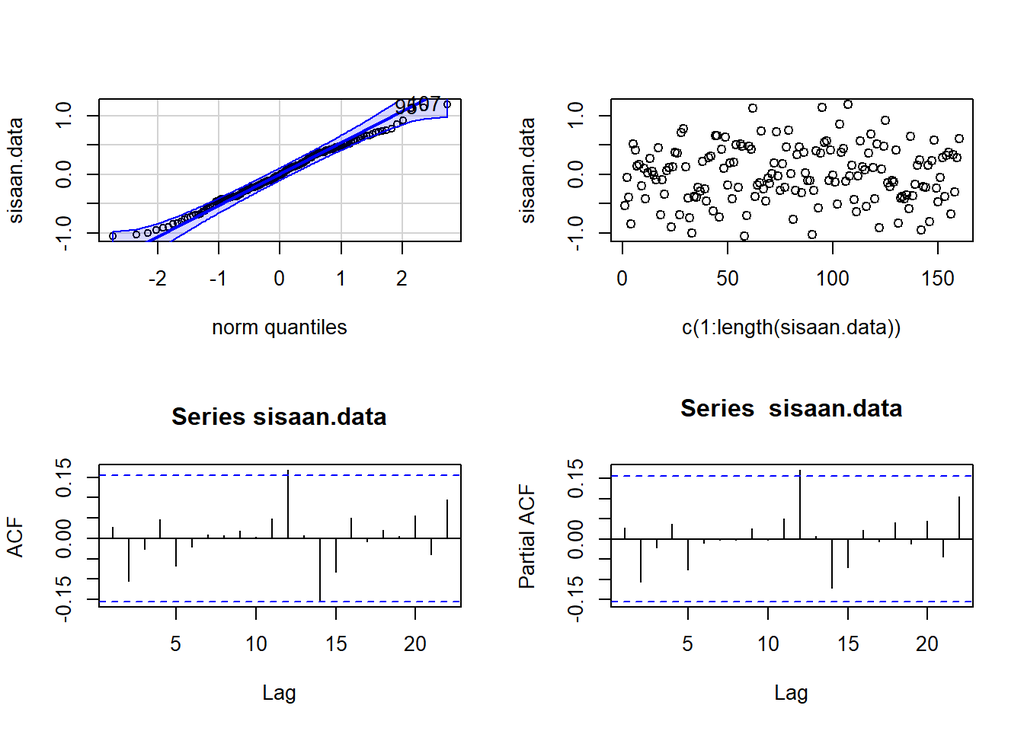

```r
plot(c(1:length(sisaan.data)),sisaan.data)
acf(sisaan.data)
pacf(sisaan.data)
```

```r
par(mfrow = c(1,1))
```

## Uji Formal

```r
#1) Sisaan Menyebar Normal
ks.test(sisaan.data,"pnorm")
```

```
##
##  Asymptotic one-sample Kolmogorov-Smirnov test
##
## data:  sisaan.data
## D = 0.18975, p-value = 1.983e-05
## alternative hypothesis: two-sided
```

```r
#tolak H0 > sisaan tidak menyebar normal
```

Selain dengan eksplorasi, asumsi tersebut dapat diuji menggunakan uji formal. Pada tahapan ini uji formal yang digunakan untuk normalitas adalah uji Kolmogorov-Smirnov (KS). Hipotesis pada uji KS adalah sebagai berikut.

$H_0$ : Sisaan menyebar normal

$H_1$ : Sisaan tidak menyebar normal

```r
#2) Sisaan saling bebas/tidak ada autokorelasi
Box.test(sisaan.data, type = "Ljung")
```

```
##
##  Box-Ljung test
##
## data:  sisaan.data
## X-squared = 0.12224, df = 1, p-value = 0.7266
```

```r
#tak tolak H0 > sisaan saling bebas
```

Selanjutnya akan dilakukan uji formal untuk kebebasan sisaan menggunakan uji Ljung-Box. Hipotesis yang digunakan adalah sebagai berikut.

$H_0$ : Sisaan saling bebas

$H_1$ : Sisaan tidak tidak saling bebas

```r
#3) Sisaan homogen
Box.test((sisaan.data)^2, type = "Ljung")
```

```
##
##  Box-Ljung test
##
## data:  (sisaan.data)^2
## X-squared = 0.38743, df = 1, p-value = 0.5337
```

```r
#tak tolak H0 > sisaan homogen
```

Hipotesis yang digunakan untuk uji kehomogenan ragam adalah sebagai berikut.

$H_0$ : Ragam sisaan homogen

$H_1$ : Ragam sisaan tidak homogen

Berdasarkan uji Ljung-Box terhadap sisaan kuadrat tersebut, didapat p-value sebesar 0.5337 yang lebih besar dari taraf nyata 5% sehingga tak tolak $H_0$ dan menandakan bahwa ragam sisaan homogen.

```r
#4) Nilai tengah sisaan sama dengan nol
t.test(sisaan.data, mu = 0, conf.level = 0.95)
```

```
##
##  One Sample t-test
##
## data:  sisaan.data
## t = -8.4629e-13, df = 159, p-value = 1
## alternative hypothesis: true mean is not equal to 0
## 95 percent confidence interval:
##  -0.07420405  0.07420405
## sample estimates:
##     mean of x
## -3.179677e-14
```

```r
#tak tolak h0 > nilai tengah sisaan sama dengan 0
```

Terakhir, dengan uji-t, akan dicek apakah nilai tengah sisaan sama dengan nol. Hipotesis yang diujikan sebagai berikut.

$H_0$ : nilai tengah sisaan sama dengan 0

$H_1$ : nilai tengah sisaan tidak sama dengan 0

# Overfitting

Tahapan selanjutnya adalah overfitting dilakukan dengan menaikkan orde AR(p) dan MA(q) dari model ARIMA(0,0,0) untuk melihat apakah terdapat model lain yang lebih baik dari model saat ini. Kandidat model overfitting adalah ARIMA(1,0,0) dan ARIMA(0,0,1).

```r
#---OVERFITTING---#
model1a.data=Arima(data.train, order=c(1,0,0),method="ML")
summary(model1a.data) #AIC = 220.88
```

```
## Series: data.train
## ARIMA(1,0,0) with non-zero mean
##
## Coefficients:
##          ar1      mean
##       0.0277  129.0221
## s.e.  0.0795    0.0385
##
## sigma^2 = 0.2271:  log likelihood = -107.44
## AIC=220.88   AICc=221.04   BIC=230.11
##
## Training set error measures:
##                        ME      RMSE       MAE          MPE      MAPE      MASE
## Training set 9.241526e-05 0.4735807 0.3900595 -0.001275745 0.3023346 0.7322251
##                     ACF1
## Training set 0.002867072
```

```r
lmtest::coeftest(model1a.data) #ar1 tidak signifikan
```

```
##
## z test of coefficients:
##
##             Estimate Std. Error   z value Pr(>|z|)
## ar1         0.027714   0.079500    0.3486   0.7274
## intercept 129.022077   0.038500 3351.1983   <2e-16 ***
## ---
## Signif. codes:  0 '***' 0.001 '**' 0.01 '*' 0.05 '.' 0.1 ' ' 1
```

```r
model1b.data=Arima(data.train, order=c(0,0,1),method="ML")
summary(model1b.data) #AIC = 220.85
```

```
## Series: data.train
## ARIMA(0,0,1) with non-zero mean
##
## Coefficients:
##          ma1      mean
##       0.0350  129.0221
## s.e.  0.0891    0.0387
##
## sigma^2 = 0.2271:  log likelihood = -107.43
## AIC=220.85   AICc=221   BIC=230.08
##
## Training set error measures:
##                        ME      RMSE       MAE         MPE      MAPE      MASE
## Training set 0.0001162652 0.4735323 0.3900633 -0.00125682 0.3023379 0.7322322
##                      ACF1
## Training set -0.003635759
```

```r
lmtest::coeftest(model1b.data) #ma1 tidak signifikan
```

```
##
## z test of coefficients:
##
##             Estimate Std. Error   z value Pr(>|z|)
## ma1         0.035019   0.089088    0.3931   0.6943
## intercept 129.022075   0.038739 3330.5561   <2e-16 ***
## ---
## Signif. codes:  0 '***' 0.001 '**' 0.01 '*' 0.05 '.' 0.1 ' ' 1
```

```r
#model yang dipilih adalah model awal, yaitu ARIMA(0,0,0)
```

Berdasarkan kedua model hasil overfitting di atas, yaitu **ARIMA(1,0,0)** dan **ARIMA(0,0,1)**, diketahui bahwa keduanya memiliki **nilai AIC yang lebih besar** dibandingkan dengan model awal **ARIMA(0,0,0)**. Selain itu, **parameter AR(1)** pada model ARIMA(1,0,0) dan **parameter MA(1)** pada model ARIMA(0,0,1) tidak signifikan secara statistik (p-value > 0,05). Oleh karena itu, **model ARIMA(0,0,0)** tetap dipertahankan sebagai model terbaik untuk digunakan pada tahap peramalan.

# Peramalan

Peramalan dilakukan menggunakan fungsi forecast() . Contoh peramalan berikut ini dilakukan untuk 70 hari ke depan.

```r
#---FORECAST---#
ramalan <- forecast::forecast(model1.data, h = 70)
ramalan
```

```
##     Point Forecast   Lo 80    Hi 80    Lo 95    Hi 95
## 161       129.0221 128.413 129.6311 128.0906 129.9535
## 162       129.0221 128.413 129.6311 128.0906 129.9535
## 163       129.0221 128.413 129.6311 128.0906 129.9535
## 164       129.0221 128.413 129.6311 128.0906 129.9535
## 165       129.0221 128.413 129.6311 128.0906 129.9535
## 166       129.0221 128.413 129.6311 128.0906 129.9535
## 167       129.0221 128.413 129.6311 128.0906 129.9535
## 168       129.0221 128.413 129.6311 128.0906 129.9535
## 169       129.0221 128.413 129.6311 128.0906 129.9535
## 170       129.0221 128.413 129.6311 128.0906 129.9535
## 171       129.0221 128.413 129.6311 128.0906 129.9535
## 172       129.0221 128.413 129.6311 128.0906 129.9535
## 173       129.0221 128.413 129.6311 128.0906 129.9535
## 174       129.0221 128.413 129.6311 128.0906 129.9535
```

[output cut: 56 more lines]

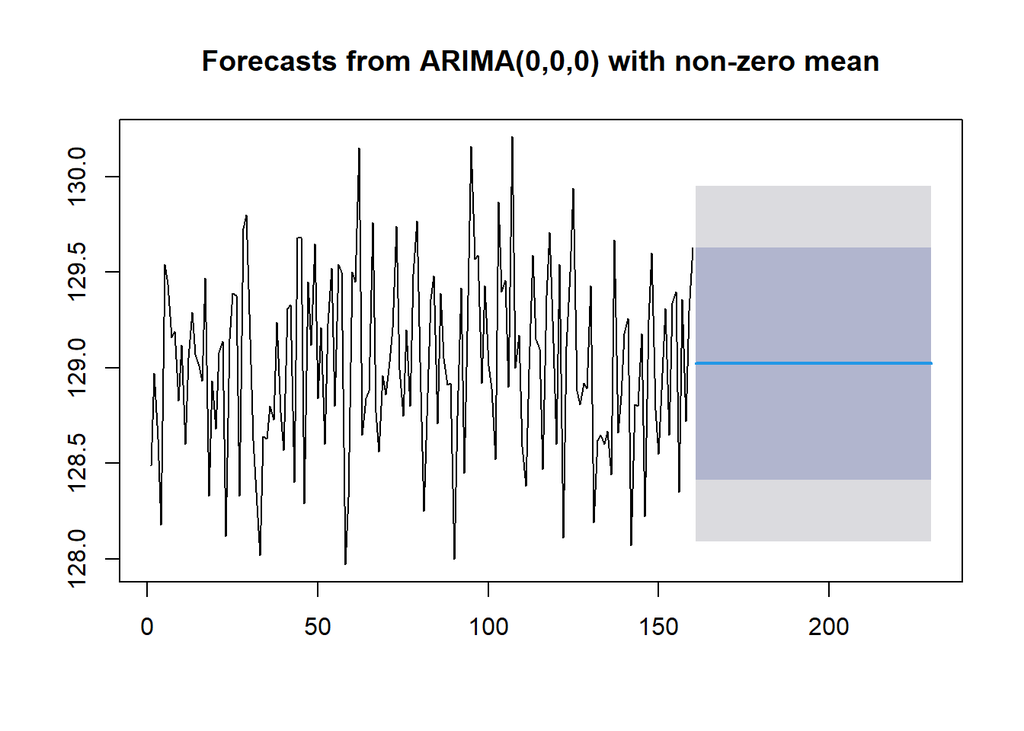

```r
data.ramalan <- ramalan$mean
plot(ramalan)
```

Berdasarkan hasil plot ramalan di atas, dapat dilihat bahwa ramalan model ARIMA(0,0,0) cenderung stabil di sekitar nilai rata-rata data historis tanpa menunjukkan adanya tren naik maupun turun yang signifikan. Hal ini sesuai dengan karakteristik model ARIMA(0,0,0) yang mengasumsikan data bersifat acak di sekitar nilai tengahnya. Selanjutnya, dapat dilakukan pengujian akurasi antara hasil ramalan dengan data uji untuk menilai kinerja model secara lebih mendalam.

```r
perbandingan<-matrix(data=c(data.test, data.ramalan),
                     nrow = 70, ncol = 2)
colnames(perbandingan)<-c("Aktual","Hasil Forecast")
perbandingan
```

```
##         Aktual Hasil Forecast
##  [1,] 128.1300       129.0221
##  [2,] 128.2000       129.0221
##  [3,] 128.6800       129.0221
##  [4,] 128.6700       129.0221
##  [5,] 129.1300       129.0221
##  [6,] 128.4400       129.0221
##  [7,] 128.6400       129.0221
##  [8,] 129.2800       129.0221
##  [9,] 128.2400       129.0221
## [10,] 129.2000       129.0221
## [11,] 129.0100       129.0221
## [12,] 128.9900       129.0221
## [13,] 128.7500       129.0221
## [14,] 129.4600       129.0221
```

[output cut: 56 more lines]

```r
accuracy(data.ramalan, data.test)
```

```
##                  ME      RMSE       MAE        MPE      MAPE
## Test set -0.1790625 0.5462366 0.4521188 -0.1405808 0.3511683
```